# Assignment 3

### Week 3 Assignment Submission - K.Maadhu

```python
import pandas as pd
import numpy as np
import statsmodels.api as sm
```

```python
from sklearn.model_selection import train_test_split
```

#### Read the dataset into a dataframe and process

```python
import os
os.chdir(r'C:\Maadhu\Jigsaw\Assignments\UC\AA&ML\Week 3')
```

```python
input_data = pd.read_csv('titanic_dataset.csv')
```

```python
input_data.dtypes
```

```
PassengerId      int64
Survived         int64
Pclass           int64
Name            object
Sex             object
Age            float64
SibSp            int64
Parch            int64
Ticket          object
Fare           float64
Cabin           object
Embarked        object
dtype: object
```

```python
input_data.head(10)
```

|  | PassengerId | Survived | Pclass | Name | Sex | Age | SibSp | Parch | Ticket | Fare | Cabin | Embarked |
| --- | --- | --- | --- | --- | --- | --- | --- | --- | --- | --- | --- | --- |
| 0 | 1 | 0 | 3 | Braund, Mr. Owen Harris | male | 22.0 | 1 | 0 | A/5 21171 | 7.2500 | NaN | S |
| 1 | 2 | 1 | 1 | Cumings, Mrs. John Bradley (Florence Briggs Th... | female | 38.0 | 1 | 0 | PC 17599 | 71.2833 | C85 | C |
| 2 | 3 | 1 | 3 | Heikkinen, Miss. Laina | female | 26.0 | 0 | 0 | STON/O2. 3101282 | 7.9250 | NaN | S |
| 3 | 4 | 1 | 1 | Futrelle, Mrs. Jacques Heath (Lily May Peel) | female | 35.0 | 1 | 0 | 113803 | 53.1000 | C123 | S |
| 4 | 5 | 0 | 3 | Allen, Mr. William Henry | male | 35.0 | 0 | 0 | 373450 | 8.0500 | NaN | S |
| 5 | 6 | 0 | 3 | Moran, Mr. James | male | NaN | 0 | 0 | 330877 | 8.4583 | NaN | Q |
| 6 | 7 | 0 | 1 | McCarthy, Mr. Timothy J | male | 54.0 | 0 | 0 | 17463 | 51.8625 | E46 | S |
| 7 | 8 | 0 | 3 | Palsson, Master. Gosta Leonard | male | 2.0 | 3 | 1 | 349909 | 21.0750 | NaN | S |
| 8 | 9 | 1 | 3 | Johnson, Mrs. Oscar W (Elisabeth Vilhelmina Berg) | female | 27.0 | 0 | 2 | 347742 | 11.1333 | NaN | S |
| 9 | 10 | 1 | 2 | Nasser, Mrs. Nicholas (Adele Achem) | female | 14.0 | 1 | 0 | 237736 | 30.0708 | NaN | C |

```python
input_data.shape
```

```
(891, 12)
```

#### Drop columns which are not significant to the final outcome

The columns which will be removed initially are Passenger ID, Name, Ticket, Fare, Cabin and Embarked

```python
input_data = input_data.drop(['PassengerId', 'Name', 'Ticket', 'Fare', 'Cabin', 'Embarked'], axis = 1)
```

#### Get the number of rows where the age is not present, and then fill it with the median value

**To get the median age from the available list and then populate that value to all the rows which doesn't have an age value**

```python
input_data['Age'].isnull().sum()
```

```
177
```

```python
np.nanmedian(input_data['Age'])
```

```
28.0
```

```python
input_data['Age'].fillna(np.nanmedian(input_data['Age']), inplace = True)
```

**Convert the Sex column to a categorical variable of numerical values**

So, all rows with Male will be coded as 1 and all rows with Female will be coded as 0.

```python
input_data['Sex_Num'] = input_data['Sex'].map({'male':1, 'female':0})
```

##### Drop the column 'Sex' which has been converted to a numerical value of 1 and 0

```python
input_data = input_data.drop('Sex', axis = 1)
```

#### Identify the correlation between all the variables before fitting the model

```python
input_data.corr()
```

|  | Survived | Pclass | Age | SibSp | Parch | Sex_Num |
| --- | --- | --- | --- | --- | --- | --- |
| Survived | 1.000000 | -0.338481 | -0.064910 | -0.035322 | 0.081629 | -0.543351 |
| Pclass | -0.338481 | 1.000000 | -0.339898 | 0.083081 | 0.018443 | 0.131900 |
| Age | -0.064910 | -0.339898 | 1.000000 | -0.233296 | -0.172482 | 0.081163 |
| SibSp | -0.035322 | 0.083081 | -0.233296 | 1.000000 | 0.414838 | -0.114631 |
| Parch | 0.081629 | 0.018443 | -0.172482 | 0.414838 | 1.000000 | -0.245489 |
| Sex_Num | -0.543351 | 0.131900 | 0.081163 | -0.114631 | -0.245489 | 1.000000 |

We notice that apart from the 'Parch' variable, all the other predictors have a negative correlation. Also, the variable 'Sex_Num' is a modified variable of the 'Sex' variable, and this shows that females had more chances of survival.

#### Create the train and test data and fit the model

```python
X_Train, X_Test, y_train, y_test = train_test_split(input_data.drop('Survived', axis = 1), input_data['Survived'], test_size = 0.3, random_state = 2)
```

Add the $ \beta0$ constant value. The below line adds a column called constant with a value of 1.0, which is used in the intercept calculation.

We are adding the constant value to the predictors in both the training and test datasets.

```python
X_Train = sm.add_constant(X_Train)
X_Test = sm.add_constant(X_Test)
```

**Run the model with all the X variables and the target y variable for the training dataset and print the results.**

The target variable in the model is the 'Survived' variable, which has the value 1 or 0, denoting the survival/death of the passenger respectively.

```python
log_reg = sm.Logit(y_train, X_Train)
```

```python
result = log_reg.fit()
```

```
Optimization terminated successfully.
         Current function value: 0.426542
         Iterations 6
```

```python
print(result.summary())
```

```
                           Logit Regression Results
==============================================================================
Dep. Variable:               Survived   No. Observations:                  623
Model:                          Logit   Df Residuals:                      617
Method:                           MLE   Df Model:                            5
Date:                Fri, 02 Nov 2018   Pseudo R-squ.:                  0.3556
Time:                        21:40:50   Log-Likelihood:                -265.74
converged:                       True   LL-Null:                       -412.34
                                        LLR p-value:                 2.873e-61
==============================================================================
                 coef    std err          z      P>|z|      [0.025      0.975]
------------------------------------------------------------------------------
const          5.5839      0.605      9.222      0.000       4.397       6.771
Pclass        -1.2152      0.148     -8.183      0.000      -1.506      -0.924
Age           -0.0490      0.010     -5.023      0.000      -0.068      -0.030
SibSp         -0.3999      0.138     -2.894      0.004      -0.671      -0.129
Parch         -0.0319      0.125     -0.254      0.799      -0.278       0.214
Sex_Num       -2.9046      0.242    -12.014      0.000      -3.378      -2.431
==============================================================================
```

```python
print(result.summary2())
```

```
                         Results: Logit
=================================================================
Model:              Logit            Pseudo R-squared: 0.356
Dependent Variable: Survived         AIC:              543.4710
Date:               2018-11-02 21:40 BIC:              570.0783
No. Observations:   623              Log-Likelihood:   -265.74
Df Model:           5                LL-Null:          -412.34
Df Residuals:       617              LLR p-value:      2.8732e-61
Converged:          1.0000           Scale:            1.0000
No. Iterations:     6.0000
------------------------------------------------------------------
              Coef.   Std.Err.     z      P>|z|    [0.025   0.975]
------------------------------------------------------------------
const         5.5839    0.6055    9.2222  0.0000   4.3972   6.7706
Pclass       -1.2152    0.1485   -8.1833  0.0000  -1.5062  -0.9241
Age          -0.0490    0.0098   -5.0229  0.0000  -0.0681  -0.0299
SibSp        -0.3999    0.1382   -2.8944  0.0038  -0.6707  -0.1291
Parch        -0.0319    0.1254   -0.2541  0.7994  -0.2776   0.2139
Sex_Num      -2.9046    0.2418  -12.0136  0.0000  -3.3785  -2.4307
=================================================================
```

### Initial Result Analysis

#### Considering the p-value from the above result summary, we see that the variable 'Parch' has a value of > 0.05.

The predictor 'Sibsp' has a p-value of < 0.05 and the other variables have a value of ZERO.

So, we shall drop this variable 'Parch' as a predictor in our next iteration and re-run the model. This is because we are assuming that we have a confidence level of 95% for our model.

```python
X_Train = X_Train.drop('Parch', axis = 1)
X_Test = X_Test.drop('Parch', axis = 1)
```

```python
log_reg_2 = sm.Logit(y_train, X_Train)
```

```python
result_2 = log_reg_2.fit()
```

```
Optimization terminated successfully.
         Current function value: 0.426594
         Iterations 6
```

```python
print(result_2.summary())
```

```
                           Logit Regression Results
==============================================================================
Dep. Variable:               Survived   No. Observations:                  623
Model:                          Logit   Df Residuals:                      618
Method:                           MLE   Df Model:                            4
Date:                Fri, 02 Nov 2018   Pseudo R-squ.:                  0.3555
Time:                        21:40:50   Log-Likelihood:                -265.77
converged:                       True   LL-Null:                       -412.34
                                        LLR p-value:                 3.247e-62
==============================================================================
                 coef    std err          z      P>|z|      [0.025      0.975]
------------------------------------------------------------------------------
const          5.5660      0.602      9.253      0.000       4.387       6.745
Pclass        -1.2157      0.149     -8.185      0.000      -1.507      -0.925
Age           -0.0489      0.010     -5.019      0.000      -0.068      -0.030
SibSp         -0.4096      0.133     -3.076      0.002      -0.671      -0.149
Sex_Num       -2.8924      0.237    -12.215      0.000      -3.357      -2.428
==============================================================================
```

```python
print(result_2.summary2())
```

```
                         Results: Logit
=================================================================
Model:              Logit            Pseudo R-squared: 0.355
Dependent Variable: Survived         AIC:              541.5359
Date:               2018-11-02 21:40 BIC:              563.7086
No. Observations:   623              Log-Likelihood:   -265.77
Df Model:           4                LL-Null:          -412.34
Df Residuals:       618              LLR p-value:      3.2465e-62
Converged:          1.0000           Scale:            1.0000
No. Iterations:     6.0000
------------------------------------------------------------------
              Coef.   Std.Err.     z      P>|z|    [0.025   0.975]
------------------------------------------------------------------
const         5.5660    0.6015    9.2531  0.0000   4.3870   6.7450
Pclass       -1.2157    0.1485   -8.1846  0.0000  -1.5069  -0.9246
Age          -0.0489    0.0097   -5.0189  0.0000  -0.0680  -0.0298
SibSp        -0.4096    0.1332   -3.0757  0.0021  -0.6706  -0.1486
Sex_Num      -2.8924    0.2368  -12.2150  0.0000  -3.3565  -2.4283
=================================================================
```

### Results Observed

**In the second model output, we notice that the 'Pesudo-$R^2$' value has not significantly changed.**

**It's also to be noted that the AIC value has decreased in the second model's output.**

Apart from the increase in the confidence level of the 'Sibsp' variable, the p-value of all the other variables has remained relatively unchanged retaining the value of ZERO.

The $\beta0$ value of the other predictors has also not changed significantely between the two iterations of the model.

**We will keep this as our final model as all the predictors are significant and the AIC has decreased.**

Identify the predictions and generate the accuracy score

```python
predictions = result_2.predict(X_Test)
```

The 'Survived' variable in our unseen test dataset is a '1' or '0' variable. The output present in the predictions variable is a continious variable, which we shall segregate into 2 using **0.5 as a midvalue**.

```python
predict_survival = np.where(predictions>0.5, 1, 0)
```

```python
np.unique(predict_survival, return_counts= True)
```

```
(array([0, 1]), array([175,  93], dtype=int64))
```

We see above that by using a midpoint of 0.5, there are 93 survivers from 268 passengers in our test dataset.

**We are generating the accuracy score here, as this model is for a binomial output where the result has a 50-50 chance.**

```python
from sklearn.metrics import accuracy_score
```

```python
accuracy_score(y_test, predict_survival)
```

```
0.7649253731343284
```

### Evaluation Metrics

**Fit the model using the to sklearn Logistic Regression model to enable metrics evaluation**

```python
from sklearn.linear_model import LogisticRegression
```

```python
rerun_logit = LogisticRegression()
```

```python
rerun_logit.fit(X_Train, y_train)
```

```
LogisticRegression(C=1.0, class_weight=None, dual=False, fit_intercept=True,
          intercept_scaling=1, max_iter=100, multi_class='ovr', n_jobs=1,
          penalty='l2', random_state=None, solver='liblinear', tol=0.0001,
          verbose=0, warm_start=False)
```

**Generating the accuracy score based on the model in the above line**

```python
rerun_logit.score(X_Test, y_test)
```

```
0.7761194029850746
```

### Create ROC Curve and find AUC and optimal cutoff probability

```python
from sklearn.metrics import roc_curve, roc_auc_score
import matplotlib.pyplot as plt
%matplotlib inline
```

```python
probability_of_predictions = rerun_logit.predict_proba(X_Test)[::,1]
```

```python
auc = roc_auc_score(y_test, probability_of_predictions)
print("The value of AUC is %0.5f" % auc)
```

```
The value of AUC is 0.82812
```

```python
fpr, tpr, threshold = roc_curve(y_test, probability_of_predictions)
```

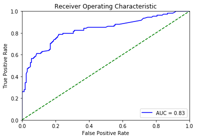

```python
plt.title('Receiver Operating Characteristic')
plt.plot(fpr, tpr, 'b', label = 'AUC = %0.2f' % auc)
plt.legend(loc = 'lower right')
plt.plot([0, 1], [0, 1], 'g--')
plt.xlim([0, 1])
plt.ylim([0, 1])
plt.xlabel('False Positive Rate')
plt.ylabel('True Positive Rate')
plt.show()
```

Calculate the optimal cutoff probability from the above ROC Curve values

```python
optimal_idx = np.argmax(tpr - fpr)
optimal_threshold = threshold[optimal_idx]
```

```python
print("The optimal threshold is %0.10f" % optimal_threshold)
```

```
The optimal threshold is 0.3132758864
```

**Update the model's predictions based on the above derived optimal threshold value**

```python
new_predict_survival = np.where(predictions > optimal_threshold, 1, 0)
```

```python
np.unique(new_predict_survival, return_counts= True)
```

```
(array([0, 1]), array([149, 119], dtype=int64))
```

We see above that by using the newly predicted survival rate based on the optimum threshold, there are 119 survivers from 268 passengers in our test dataset.

Generate the accuracy score again based on the new predictons value.

```python
accuracy_score(y_test, new_predict_survival)
```

```
0.7873134328358209
```

**The above improved accuracy score shows that our new model is better than the old model.**

### Create the Confusion matrix based on the new predictions

```python
from sklearn.metrics import confusion_matrix
import seaborn as sb
```

```python
conf_mat = confusion_matrix(y_test, new_predict_survival)
```

```python
confusion_df = pd.DataFrame(conf_mat, index=['Actual Neg','Actual Pos'], columns=['Predicted Neg','Predicted Pos'])
```

```python
confusion_df
```

|  | Predicted Neg | Predicted Pos |
| --- | --- | --- |
| Actual Neg | 126 | 34 |
| Actual Pos | 23 | 85 |

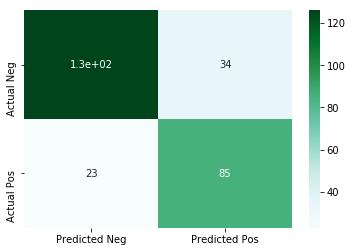

```python
_=sb.heatmap(confusion_df, cmap='BuGn', annot= True)
```

**Generate other scores for the model**

```python
accuracy_score(y_test, new_predict_survival, normalize=False)
```

```
211
```

Using the above answer, as there are 268 number of passengers present in our test dataset, the incorrectly predicted observations is given below.

```python
len(y_test) - accuracy_score(y_test, new_predict_survival, normalize=False)
```

```
57
```

**Calculate Log Loss, Precision, Recall and F1 scores**

```python
from sklearn.metrics import log_loss, precision_score, recall_score, f1_score
```

```python
log_loss(y_test, new_predict_survival)
```

```
7.346035226949759
```

```python
precision_score(y_test, new_predict_survival)
```

```
0.7142857142857143
```

```python
recall_score(y_test, new_predict_survival)
```

```
0.7870370370370371
```

```python
f1_score(y_test, new_predict_survival)
```

```
0.748898678414097
```